# Gender Clumping in Gov 1006

David Kane

2/12/2020

Do students clump by gender in Gov 1006?

Let’s ignore the table with all graduate students, since this will never clump. Let’s ignore the table with two graduate students. (It is always a good idea to make the initial version of a simulation as simple as possible.) There are 30 remaining students: 16 men and 14 women. Our null model is that they sit down randomly. We can ignore the last two students since they are, by assumption, sitting at the table with 2 graduate students. This leaves us with 28 students (chosen randomly from the 30 undergraduates) sitting at 7 tables of 4 students each.

Define a “clump” as a table of four, all of the same gender. (Other definitions of clumping are possible. One aspect of data science is going from a verbal description to a mathematical formulation.) In class on February 12th, there were three such tables. Is that surprising? Is it evidence of clumping? If students sat randomly, how unusual would it be to see three single-gender tables?

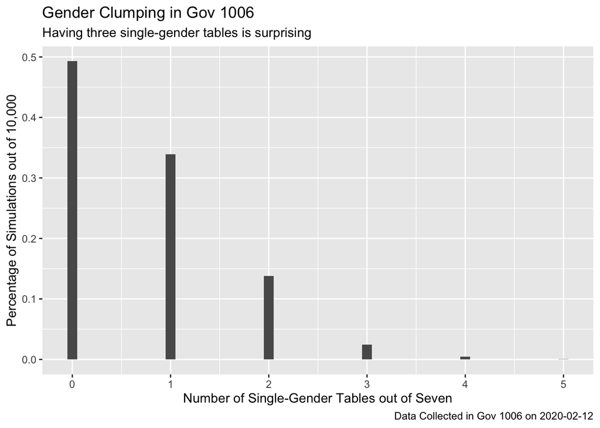